# Regularization_and_Cross_Validation_HW

## Question #2: Machine Learning Theory

**Purpose: Demonstrate Theory of Lecture Material**

1. Lambda: What is lambda in Ridge, Lasso and Elastic Net regression? What is its function?

```r
# Lambda is a tuning parameter, it is the sum of the squared coefficient estimates. It is used to scale the Beta coefficients so that there is a penalty for large betas when trying to minimize the RSS.
```

2. Cross Validation: What is the purpose of doing cross validation? Explain the k-fold cross validation process.

```r
# Cross validation is used to test how well a ML model can predict new values with new data. The original training data is split so that some of it can be used to train the model and the other part can be used to test how well the model does. K-fold CV is when you split the data into k equal parts. Over k times, one of the subsets is used for testing while the other k-1 are combined and used for training. Then the resulting error of all trials is averaged.
```

3. Cross Validation: How should we choose cross validation folds typically? What does it mean when we choose a larger number of k-fold?

```r
# Typically k should be 5 or 10. The larger k is, the smaller the subset of the data to be tested and the larger the data to be used for training. This will lower the vairance but introduce more bias.
```

## Question #3:Challenge Questions- Lasso Regression

1. Lasso Regression: Repeat the entire analysis performed in question #1, but use the lasso regression method this time.

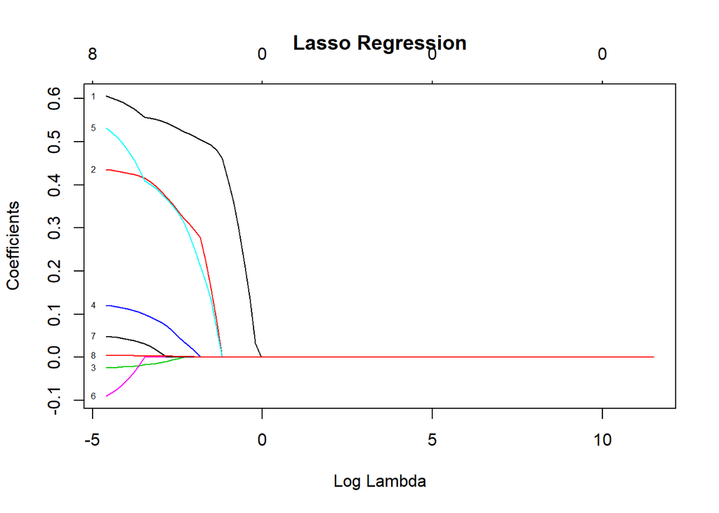

```r
set.seed(0)
lasso.models = glmnet(x, y, alpha = 1, lambda = grid)
lasso_coefs = coef(ridge.models)

plot(lasso.models, xvar = "lambda", label = TRUE, main = "Lasso Regression")
```

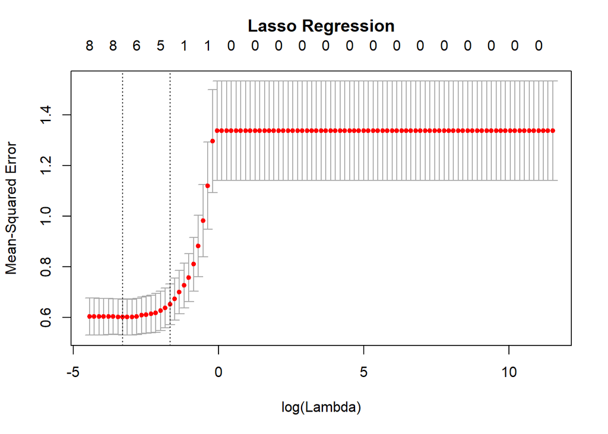

```r
cv.lasso.out = cv.glmnet(x, y,
                         lambda = grid, alpha = 1, nfolds = 10)
plot(cv.lasso.out, main = "Lasso Regression\n")
```

```r
best.lambda.lasso = cv.lasso.out$lambda.min
best.lambda.lasso
```

```
## [1] 0.0367838
```

```r
log(best.lambda.lasso)
```

```
## [1] -3.302698
```

```r
lasso.models.train = glmnet(x.test, y.test, alpha = 1, lambda = grid)
lasso.bestlambdatrain = predict(lasso.models.train, s = best.lambda.lasso, newx = x.test)
summary(lasso.bestlambdatrain)
```

```
##        1
##  Min.   :0.9125
##  1st Qu.:2.0155
##  Median :2.4701
##  Mean   :2.6407
##  3rd Qu.:3.2361
##  Max.   :4.5739
```

```r
mean((lasso.bestlambdatrain - y.test)^2)
```

```
## [1] 0.3270081
```

2. Compare: Compare your final ridge and lasso models. Which one would you choose to use? Why?